# Profile performance analysis

Uayeb Caballero

30 de abril de 2020

## Introducción

En este pequeño analisis vamos a estudiar cuales son las caracteristicas de los estudiantes con mayor riesgo a tener un desempeño academico bajo. la recolección de información se realizo mediante encuestan en aplicadas a los alumnos de base de datos I y programación orientada a objetos. Sabemos que es de gran importancia para los docentes la Universidad Nacional Autonoma de Honduras conocer mejors a sus alumnos y planificar intervenciones mas efectivas por lo que este estudio demuestra cuales deberian de ser esos driver a tener en cuenta al inicio del periodo academico.

## Variables capturadas

```
## 'data.frame':    33 obs. of  41 variables:
##  $ Timestamp                  : chr  "3/28/2020 15:38:41" "3/28/2020 15:40:34" "3/28/2020 15:42:24" "3/28/2020 15:42:34" ...
##  $ genero                     : chr  "Mujer" "Hombre" "Hombre" "Hombre" ...
##  $ edad                       : chr  "20-25" "20-25" "20-25" "20-25" ...
##  $ horas_llegar_unah          : chr  "Normal" "Muchas" "Pocas" "Pocas" ...
##  $ internet_permanente        : chr  "No" "Sí" "Sí" "Sí" ...
##  $ buena_conexion             : chr  "" "Sí" "Sí" "No" ...
##  $ trabaja                    : chr  "Sí" "Sí" "No" "No" ...
##  $ familiares_graduados       : chr  "Sí" "No" "Sí" "No" ...
##  $ familiares_estudiando      : chr  "No" "Sí" "Sí" "Sí" ...
##  $ ejemplos_a_seguir          : chr  "" "No" "Sí" "No" ...
##  $ foraneo                    : chr  "No" "No" "No" "Sí" ...
##  $ multiple_carrera           : chr  "No" "No" "No" "No" ...
##  $ otras_opciones_estudio     : chr  "Administración de empresas " "Economía, Mercadotecnia, Banca y finanzas, en general toda el área financiera y administrativa me gusta. " "Medicina" "Mercadotecnia " ...
##  $ numero_periodos_matriculado: int  21 14 11 13 12 14 20 12 NA NA ...
```

[output cut: 27 more lines]

A continuación mostramos un resumen rapido de cada una de nuestra columnas:

```r
summary(survey)
```

```
##   Timestamp            genero              edad           horas_llegar_unah
##  Length:33          Length:33          Length:33          Length:33
##  Class :character   Class :character   Class :character   Class :character
##  Mode  :character   Mode  :character   Mode  :character   Mode  :character
##
##
##
##
##  internet_permanente buena_conexion       trabaja          familiares_graduados
##  Length:33           Length:33          Length:33          Length:33
##  Class :character    Class :character   Class :character   Class :character
##  Mode  :character    Mode  :character   Mode  :character   Mode  :character
##
##
##
##
##  familiares_estudiando ejemplos_a_seguir    foraneo          multiple_carrera
##  Length:33             Length:33          Length:33          Length:33
##  Class :character      Class :character   Class :character   Class :character
##  Mode  :character      Mode  :character   Mode  :character   Mode  :character
##
##
##
##
##  otras_opciones_estudio numero_periodos_matriculado    indice
##  Length:33              Min.   : 7.0                Length:33
##  Class :character       1st Qu.:10.0                Class :character
##  Mode  :character       Median :12.0                Mode  :character
##                         Mean   :12.5
##                         3rd Qu.:14.0
##                         Max.   :21.0
##                         NA's   :3
##  excelencia_academica  reprobado         reprobado_mas_de_dos
##  Length:33            Length:33          Length:33
##  Class :character     Class :character   Class :character
##  Mode  :character     Mode  :character   Mode  :character
##
##
##
##
```

[output cut: 41 more lines]

```
##  Length:33          Length:33          Length:33          Length:33
##  Class :character   Class :character   Class :character   Class :character
##  Mode  :character   Mode  :character   Mode  :character   Mode  :character
##
##
##
##
##       nota
##  Min.   :1.000
##  1st Qu.:4.800
##  Median :7.500
##  Mean   :6.458
##  3rd Qu.:8.800
##  Max.   :9.600
##
```

## Tratamiento de columnas

Uno de los tratamientos tipicos es la deteccion de valores nulos y según la regla de negocio realizar algún tipo de transformación. por ejemplo, nuestro dataset mostro los siguientes valores nulos

```
##                   column.name na.percentage
## 1                  anios_beca    0.93939394
## 2 numero_periodos_matriculado    0.09090909
```

### Tratamiento de anios_becas

Si analizamos anios_beca podremos encontrar la siguiente información

```r
summary(survey$anios_beca)
```

```
##    Min. 1st Qu.  Median    Mean 3rd Qu.    Max.    NA's
##    2.00    2.25    2.50    2.50    2.75    3.00      31
```

31 NA’s en una columna donde saber que los NA’s se pueden interpretar como ceros, por eso imputamos esos valores por el valor sugerido.

```r
survey[is.na(survey$anios_beca),"anios_beca"] <- 0
summary(survey$anios_beca)
```

```
##    Min. 1st Qu.  Median    Mean 3rd Qu.    Max.
##  0.0000  0.0000  0.0000  0.1515  0.0000  3.0000
```

## Analisis descriptivo de datos

En esta seccion comenzamos a sugerir un par de transformacion en funcion de su caracteristicas e interpretación, como por ejemplo:

#### Jornada

```r
df_perc <- as.data.frame(prop.table(table(survey$jornada)))
df_perc <- df_perc %>% arrange(-Freq)

df_perc
```

```
##                   Var1      Freq
## 1         Tarde, Noche 0.3030303
## 2                Noche 0.2424242
## 3 Mañana, Tarde, Noche 0.1818182
## 4        Mañana, Noche 0.1515152
## 5                Tarde 0.1212121
```

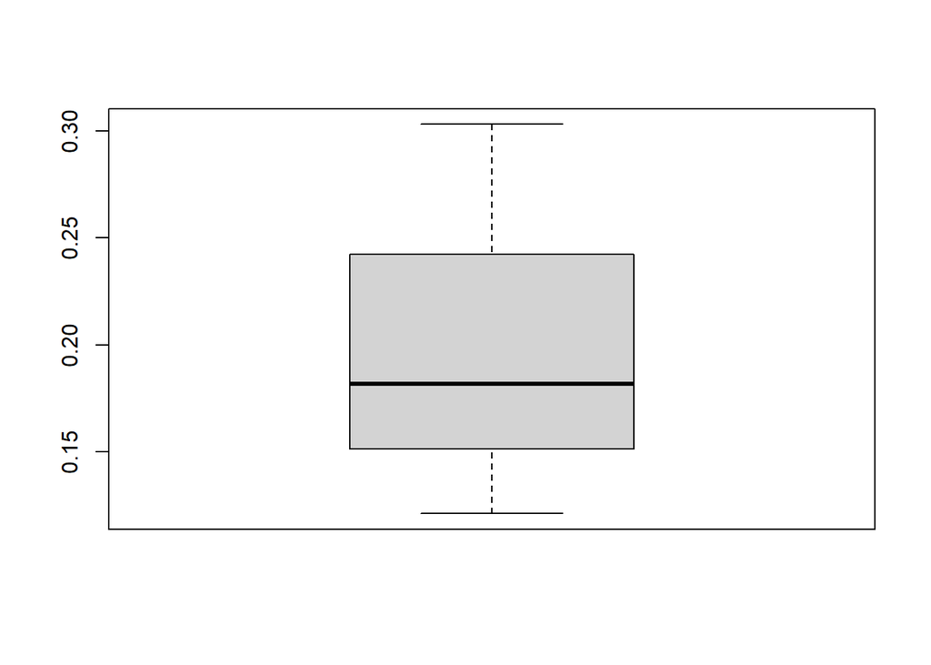

```r
boxplot(df_perc$Freq)
```

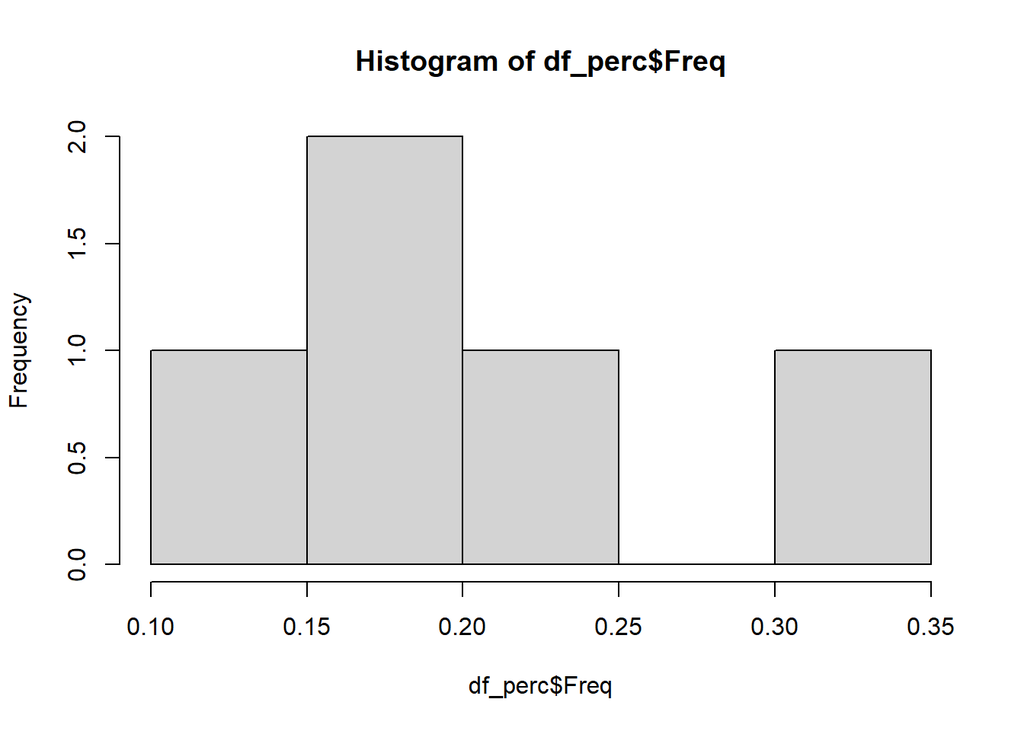

```r
hist(df_perc$Freq)
```

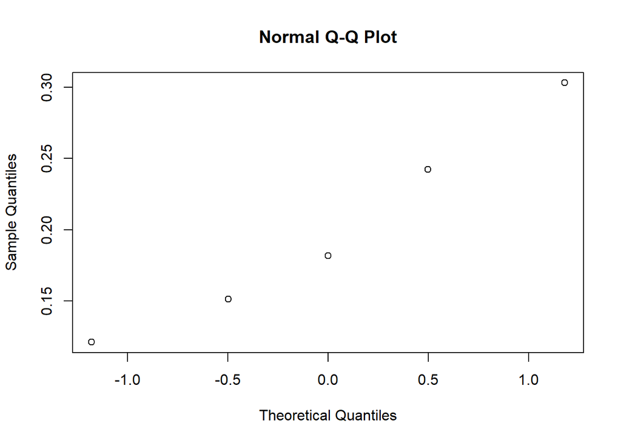

```r
qqnorm(df_perc$Freq)
```

```r
df_perc[df_perc$Var1 %in% c("Mañana, Tarde, Noche","Mañana, Noche") , "categoria"] <- "Jornada Completa"
df_perc[df_perc$Var1 %in% c("Tarde","Noche") , "categoria"] <- "Unica Jornada"
df_perc[df_perc$Var1 %in% c("Tarde, Noche") , "categoria"] <- "Doble Jornada"

df_perc <- df_perc %>% select(Var1,categoria)

survey <- left_join(survey,df_perc,by=c("jornada"="Var1"))
survey <- survey[,!(names(survey) %in% c("jornada"))]

names(survey)[length(names(survey))] <- "jornada"
prop.table(table(survey$jornada))
```

```
##
##    Doble Jornada Jornada Completa    Unica Jornada
##        0.3030303        0.3333333        0.3636364
```

## Correlaciones

```r
prop.table(table(survey$indice,survey$trabaja),1)
```

```
##
##                                No        Sí
##   <= 60                 1.0000000 0.0000000
##   61 - 70               0.6000000 0.4000000
##   71 - 80               0.4705882 0.5294118
##   81 - 90               1.0000000 0.0000000
##   Prefiero no responder 1.0000000 0.0000000
```

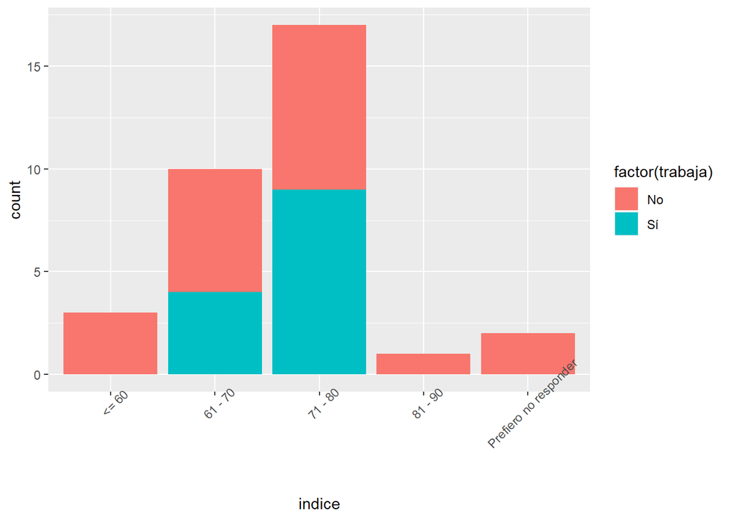

```r
ggplot(survey) +
  aes(x = indice, fill = factor(trabaja)) +
  geom_bar(position = "stack") +
  theme(axis.text.x = element_text(angle = 45))
```

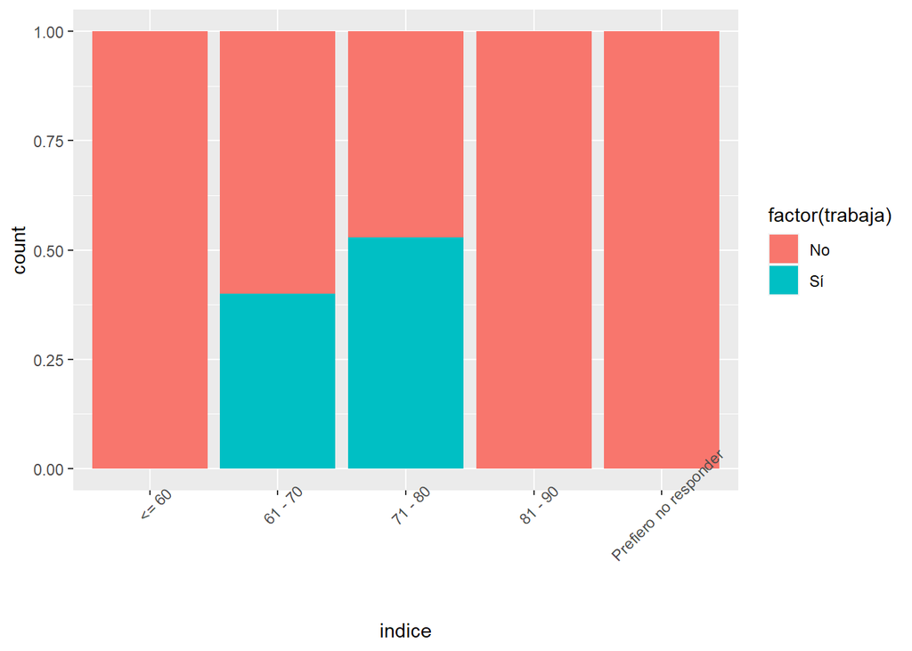

```r
ggplot(survey) +
  aes(x = indice, fill = factor(trabaja)) +
  geom_bar(position = "fill") +
  theme(axis.text.x = element_text(angle = 45))
```

```r
chisq.test(table(survey$indice,survey$trabaja))
```

```
##
##  Pearson's Chi-squared test
##
## data:  table(survey$indice, survey$trabaja)
## X-squared = 5.2083, df = 4, p-value = 0.2666
```

H_0: Las categorias de indice y trabaja son independientes. H_A: Las categorias son dependientes.